# Course introduction

Forensic phonetics, forensic linguistics, and this course

Dr Massimiliano Canzi

# Introduction

`Did you know:` the superb lyrebird of south-eastern Australia is one of the best vocal mimics known. About 80% of a male’s song is made of imitations of other species, mostly other birds, and the imitations are remarkably accurate.

*Sources: Wildlife Victoria; Dalziell et al. (2012), Animal Behaviour*

## Who I am

I am Dr Massimiliano Canzi, Max for short.

I studied linguistics in Milan (BA), Manchester (MA) and York (MSc), and returned to Manchester for my PhD.

I work on how listeners perceive speech and how speakers produce it, mostly with experiments and quantitative methods. Forensic speech science is one of my interests.

## Who are you?

Tell us briefly:

- Your name and your programme
- How much phonetics you have done so far
- A forensic case involving speech or language that you have heard of, in the news, in a podcast or on TV
- One thing you would like to take away from this course

# The course

`Did you know:` female superb lyrebirds also sing and mimic, especially when defending their nests, when they imitate predators and alarm calls. Their songs were long overlooked: adult females look almost identical to young males, so singing females were easily taken for males.

*Source: Dalziell & Welbergen (2016), Frontiers in Ecology and Evolution*

## Assessment

[output not shown]

Details follow on Ilias.

## The book

Leemann, A., Perkins, R., Sullivan Buker, G., & Foulkes, P. (2024). *An Introduction to Forensic Phonetics and Forensic Linguistics*. Routledge.

- Written by practitioners and researchers in both fields
- Real cases, exercises and suggestions for further reading in every chapter
- We cover the forensic phonetics part (chapters 1 to 7), two sessions on forensic linguistics, and chapter 13 on expert witnesses

## Syllabus

Chapters of Leemann et al. (2024):

|  | Session | Chapter |
| --- | --- | --- |
| 1 | Course introduction | 1 |
| 2 | Phonetic analysis | 2 |
| 3 | Speaker profiling | 3 |
| 4 | Speaker comparison | 4 |
| 5 | Earwitness evidence | 5 |
| 6 | Authentication, enhancement and speech content | 6 |
| 7 | Linguistic analysis in the asylum procedure | 7 |
| 8 | Language in the legal process | 10 |
| 9 | Authorship analysis | 11, 12 |
| 10 | Expert witnesses | 13 |
| 11 | Praat practical 1: measuring your own voice | 2, 4 |
| 12 | Praat practical 2: casework with the class recordings | 3–5 |

## Slides and materials

The slides are written in R Markdown and shown with `reveal.js`. Each week you get the slides (.html) and the readings.

The figures use simulated data: realistic numbers, made up for teaching. The code behind every figure is in the .Rmd file, at `github.com/mcanzi/ws27_fss`, if you are curious. You do not need `R` for this course.

## Exercises

The book has exercises in every chapter, and we do many of them together.

- Forensic questions often have no single correct answer, so we discuss how you reached yours and how sure you can be
- Try each exercise before you read the solution

## Recording your voice

For the Praat practicals (sessions 11 and 12), each of you records yourself once in the LingLab booth, at any time before session 11. It takes about 15 minutes.

| Item | Content | File name |
| --- | --- | --- |
| Word list | 19 words in the frame *Say ___ again*, read three times | `S07_words.wav` |
| Sentences A | three sentences, read normally | `S07_A.wav` |
| Sentences B | three other sentences, read normally | `S07_B.wav` |
| Disguise | sentences A again, in a disguised voice | `S07_A_disguise.wav` |

Use the ID you receive in place of S07, and upload the four files to the course folder.

## The word list

Read each word in the frame *Say ___ again*, for example *Say heed again*:

| heed | hid | head | had |
| --- | --- | --- | --- |
| hard | hod | hoard | hood |
| who’d | heard | hud | think |
| this | three | car | nurse |
| water | butter | little |  |

Read the whole list three times, at your normal speed. The first eleven words differ only in the vowel; the others contain sounds that vary across accents of English.

## Sentences A and B

| Set A | Set B |
| --- | --- |
| The north wind blew hard across the dark water all night. | In the dark, the water looked cold and much deeper than it was. |
| My sister thinks the red car parked by the school is hers. | Nobody thinks a car like that belongs in such a quiet street. |
| We heard the news on the radio and called two friends at once. | They heard a loud noise and ran back to the house. |

Read each set at your normal speed, as one short text.

## The disguised reading

- Read set A once more, in a voice that you think would stop your classmates from recognising you. Choose your own strategy, for example a different pitch, a different accent, a creaky or nasal voice. Do not whisper: we need f0
- Write down your strategy on the form you receive, and do not tell your classmates

## What this course is, and is not

This course gives you a grounding in the methods and problems of forensic speech science, and can be a first step towards further study. Forensic phoneticians train for years, at postgraduate level and in forensic labs.

It does not qualify you to do casework, and the book’s authors say the same about their book.

# Forensic phonetics and linguistics

`Did you know:` a lyrebird raised in captivity in New South Wales in the 1920s is said to have learnt flute tunes and passed them on to wild lyrebirds after its release. Flute-like songs can still be heard there, but recordings made over 40 years suggest that the local song has stayed stable over that period.

*Sources: Powys, Taylor & Probets (2013), Environmental Humanities; Probets, Taylor & Powys (2020), Corella*

## Two fields

- Forensic phonetics deals with speech and voices as evidence: who is speaking and what was said, or whether a recording has been edited
- Forensic linguistics deals with language as evidence, from the authorship of a text (session 9) to the language of police interviews and courtrooms (session 8)

Despite the names, few practitioners work in both. Most specialise further, so casework is often done by teams.

## Where the fields meet

- Language analysis in the asylum procedure (LAAP): where does an asylum seeker’s speech suggest they grew up? (session 7)
- Record keeping, report writing and acting as an expert witness: the same principles apply in both fields, and in all forensic sciences (session 10)

## You do it every day

When you answer the phone, you analyse the first few words, usually without noticing:

- Do I know this voice?
- Does it match the name on the screen?
- Roughly how old is the caller, and do they sound local?
- Do they sound calm?

Forensic phonetics asks similar questions, with systematic methods and an estimate of how reliable each answer is.

## An old idea: shibboleth

> And the Gileadites took the passages of Jordan before the Ephraimites: and it was so, that when those Ephraimites which were escaped said, Let me go over; that the men of Gilead said unto him, Art thou an Ephraimite? If he said, Nay; Then said they unto him, Say now Shibboleth: and he said Sibboleth: for he could not frame to pronounce it right.

*Judges 12:5–6, King James Bible*

A crude speaker profile: /ʃ/ for Gileadites, /s/ for Ephraimites.

## A recent shibboleth

- In 2022, Ukrainians reportedly asked strangers to say паляниця (*palianytsia*, a kind of bread) to unmask Russian saboteurs (Hyde, 2022)
- The word was believed to be hard to pronounce for speakers of Russian
- *Shibboleth* itself is now an everyday word for any sign of group membership

## Discussion

Is the pronunciation of one word enough to tell where someone is from?

- What else could explain the “wrong” pronunciation?
- What if the speaker knows the test?
- What happens if the test gets it wrong?

No: a single word is not a sound basis for a legal decision, and the book makes the same point. Session 3 covers how profiling is actually done.

## No two samples are the same

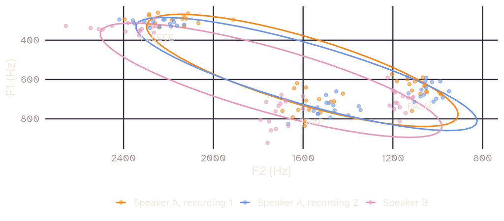

Simulated vowels: the same speaker never says a vowel twice the same way, and different speakers overlap.

## What the book covers

| Chapter | Question |
| --- | --- |
| 3 Speaker profiling | What can a voice tell us about the speaker? |
| 4 Speaker comparison | Do two recordings come from the same speaker? |
| 5 Earwitness evidence | Can a witness recognise a voice they heard? |
| 6 Authentication, enhancement, content | Is the recording genuine? What was said? |
| 7 LAAP | Where did an asylum seeker grow up? |
| 13 Expert witnesses | How do experts report, and what do courts do with it? |

# Beware the CSI effect

`Did you know:` lyrebirds are famous for imitating chainsaws and other machines. But the well-known recordings come from captive birds, such as one at Adelaide Zoo: as of 2014, no recording was known of a wild lyrebird mimicking a mechanical sound.

*Source: Taylor (2014), The Conversation*

## Forensic science on TV

- Experts collect samples, interview suspects and analyse everything, alone
- Results arrive in seconds, from impressive software
- Conclusions are a match or a mismatch, “with 99.4% certainty”
- A “voiceprint” on screen matches a stored sample perfectly

## Forensic science in reality

- Analyses take days
- Experts rarely, if ever, report “match” or “mismatch”: there is almost always some doubt
- Objectivity and transparency matter more than speed
- No two samples of speech are ever identical, so there is no such thing as a voice “match”

## Even DNA is not a “match”

- A DNA sample from a crime scene is identical to the suspect’s DNA
- This does not mean the suspect committed the crime: it means they could have
- So could everyone else who shares that profile, possibly thousands of people
- Other evidence, such as where the suspect was or a motive, is for the court to weigh

## Two propositions

The expert weighs the evidence under two competing propositions:

- Prosecution: the two samples come from the same source
- Defence: the two samples come from different sources

## Similar is not enough

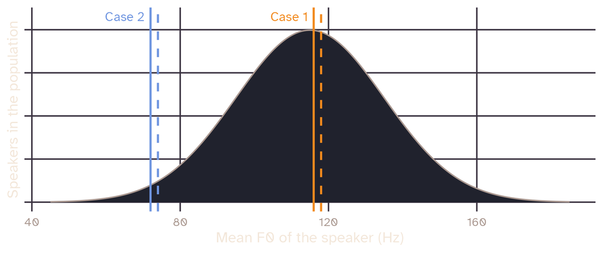

Simulated mean F0 of adult male speakers. Solid: offender. Dashed: suspect.

## Similar is not enough

In both cases, the offender and the suspect differ by only 2 Hz. But:

- Case 1: about 20% of speakers have a mean F0 within 5 Hz of the offender’s
- Case 2: only about 2.1% do

The 2 Hz difference is much stronger evidence in case 2, because so few speakers have such a low F0. How common a feature is in the population is called its typicality.

## Discussion

A TV expert says: “The voices match, with 99.4% certainty.”

- What could the 99.4% possibly mean, and what would you need to know to judge it?
- Who should decide whether the suspect is guilty?

# Working with forensic data

`Did you know:` while courting, a male superb lyrebird imitates a whole mobbing flock: the alarm calls of several species harassing a predator. He does it when a female tries to leave and during mating, although no predator is around: an acoustic illusion that may keep her from leaving.

*Source: Dalziell et al. (2021), Current Biology*

## The material

- Forensic material ranges from the mundane (phone calls about bank transfers) to the distressing (threats, recordings of crimes)
- Practitioners describe three main strains: graphic content, pressure, and cases that touch on personal experience (Giménez, Elstein & Queralt, 2020)
- In this course we only work with the cases discussed in the book

## Offenders and victims

- Notorious offenders are widely remembered; their victims much less so
- In 2019, New Zealand’s Prime Minister Jacinda Ardern refused to name the man who attacked two mosques in Christchurch
- Forensic analyses often focus on the person who produced the speech, often the offender: the book asks readers to keep the people harmed in view, and to choose their words with care

## Ethics

- Know the limits of your expertise and of your methods, and never comment beyond them
- Be objective: no conclusion stronger or weaker than the analysis supports
- The expert’s duty is to the court, whichever side asked for the report
- The accused is presumed innocent: if the evidence leaves doubt, the court must know

## Further resources

- [IAFPA](https://www.iafpa.net/): the International Association for Forensic Phonetics and Acoustics
- [IAFLL](https://iafll.org/): the International Association for Forensic and Legal Linguistics
- *International Journal of Speech, Language and the Law*
- Nolan, McDougall & Hudson (eds.) (in press), *The Oxford Handbook of Forensic Phonetics*
- [Forensic Transcription Australia](https://forensictranscription.com.au/): Helen Fraser’s site on transcripts of covert recordings

## Summary

- Forensic phonetics treats speech as evidence; forensic linguistics treats language as evidence
- No two speech samples are identical, so experts weigh similarities and differences and do not declare a “match”
- Similarity counts only together with typicality
- The expert assists the court, objectively, within the limits of their expertise
- Cases involve real people, victims included, so we describe them with care

## References

- Leemann, A., Perkins, R., Sullivan Buker, G., & Foulkes, P. (2024). *An Introduction to Forensic Phonetics and Forensic Linguistics*. Routledge. Chapter 1.
- Giménez, R., Elstein, S., & Queralt, S. (2020). The pandemic and the forensic linguistics caseworker’s wellbeing: Effects and recommendations. *International Journal of Speech, Language and the Law*, 27(2), 233–254. https://doi.org/10.1558/ijsll.19548
- Hyde, L. (2022, February 26). Saboteurs spark suspicion and solidarity in Kyiv. *Politico*.

## Sources of the animal facts

- Dalziell, A. H., Maisey, A. C., Magrath, R. D., & Welbergen, J. A. (2021). Male lyrebirds create a complex acoustic illusion of a mobbing flock during courtship and copulation. *Current Biology*, 31(9), 1970–1976. https://doi.org/10.1016/j.cub.2021.02.003
- Dalziell, A. H., & Welbergen, J. A. (2016). Elaborate mimetic vocal displays by female superb lyrebirds. *Frontiers in Ecology and Evolution*, 4, 34. https://doi.org/10.3389/fevo.2016.00034
- Dalziell, A. H., Welbergen, J. A., Igic, B., & Magrath, R. D. (2012). Fooling the experts: Accurate vocal mimicry in the song of the superb lyrebird. *Animal Behaviour*, 83, 1401–1410. https://doi.org/10.1016/j.anbehav.2012.03.009
- Powys, V., Taylor, H., & Probets, C. (2013). A little flute music: Mimicry, memory, and narrativity. *Environmental Humanities*, 3, 43–70. https://doi.org/10.1215/22011919-3611230
- Probets, C., Taylor, H., & Powys, V. (2020). A sonographic analysis of a flute-like dialect in territorial songs of the superb lyrebird *Menura novaehollandiae* in the New South Wales North Coast and New England Tableland bioregions. *Corella*.
- Taylor, H. (2014). Lyrebirds mimicking chainsaws: Fact or lie? *The Conversation*.
- Wildlife Victoria. Superb lyrebird. https://wildlifevictoria.org.au/learn/native-species-post/superb-lyrebird/

## Slides and code

[figure not shown]

These slides

mcanzi.de/ws27_fss/01_course_introduction.html

Code and all sessions

github.com/mcanzi/ws27_fss